# Homework 2

In conclusion, *there is a significant difference* in the mean number of premature beats per minutes between the before and after groups. The *p value is 0.01763*, which is < 0.05 and means we can reject our H0. Also, because our 95% CI (2.423084 20.576916) does not include 0, then we know the mean difference between the pair is not equal to 0, it is 11.5.

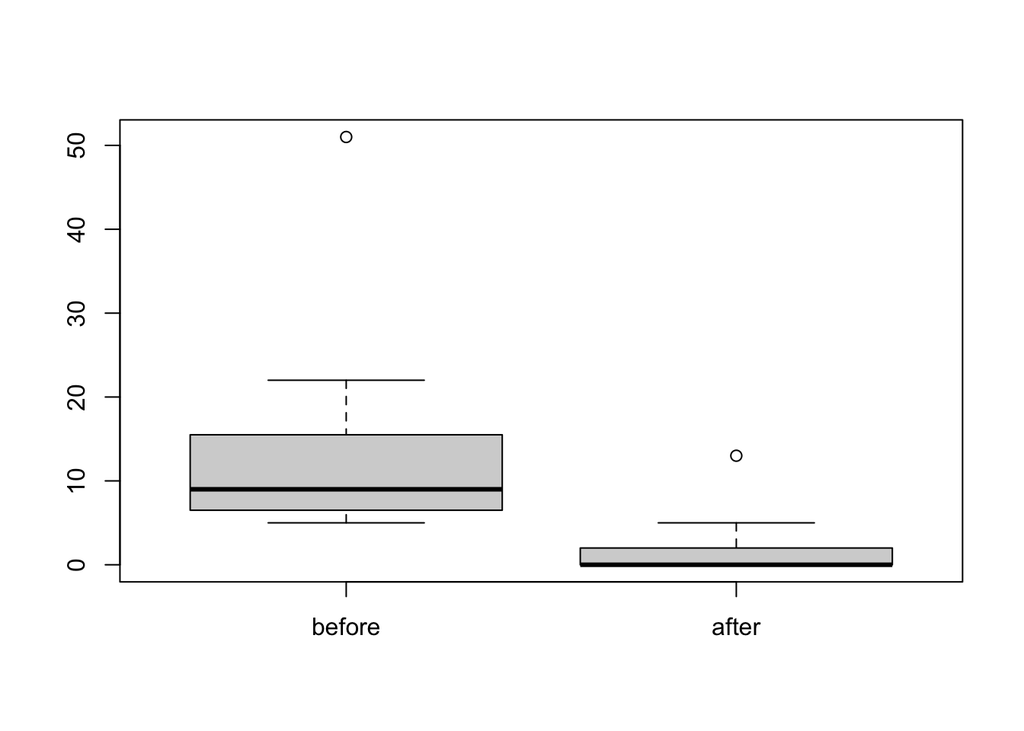

```r
## upload data
before <- c(6,9,17,22,7,5,5,14,9,7,9,51)
after <- c(5,2,0,0,2,1,0,0,0,0,13,0)
dif <- c(1,7,17,22,5,4,5,14,9,7,-4,51)
patient <- c(1:12)

patients <- cbind(before, after)

## visualize data

# check distribution
#hist(before)
#hist(after)

# check outliers
boxplot(patients)
```

```r
t.test(before, after, paired = T)
```

```
##
##  Paired t-test
##
## data:  before and after
## t = 2.7885, df = 11, p-value = 0.01763
## alternative hypothesis: true difference in means is not equal to 0
## 95 percent confidence interval:
##   2.423084 20.576916
## sample estimates:
## mean of the differences
##                    11.5
```

```r
# p-value = 0.01763
# 2.423084 - 20.576916
```

4. ANSWER: I would run a *two Sample t-test (equal variance)* because we are comparing the mean between two groups (oxygen vs placebo gel). The distribution of both groups is trending normal, although there are two outliers in the placebo group which skews it a bit. And the variances are equal (p = 0.2261).
- H0 (null hypothesis): There is no difference in the mean oral hygiene index between the oxygen gel and placebo gel. (mu_oxygen = mu_placebo)
- HA (alternative hypothesis): There is a difference in the mean oral hygiene index between the oxygen gel and placebo gel.

In conclusion, *there is a significant difference* in the mean oral hygiene index between the oxygen gel and placebo gel. The *p value is 0.001077*, which is < 0.05 and means we can reject our H0. Also, because our 95% CI (1.519477 - 5.762876) does not include 0, then we know the mean of both groups are not equal to 0. The mean oral index for oxygen gel and placebo gel, is 8.20 and 4.56, respectively.

```r
## upload data
oxygen <- c(10,15,6,10,11,4,10,15,11,5,3,8,8,3,13,14,7,8,8,2,10,9,8,9,8,13,6,2,7,3)

placebo <- c(5,6,4,3,3,2,3,6,0,3,3,3,13,4,5,6,4,4,2,-3,1,6,6,8,0,7,0,3,2,2,12,24,5,3)

gel <- cbind(oxygen, placebo)
```

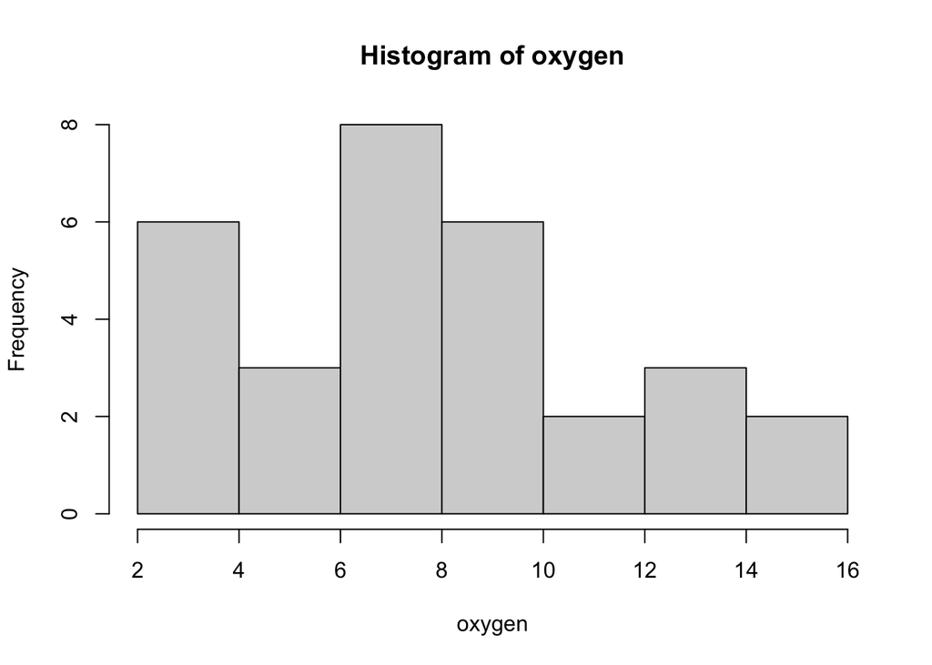

```r
## visualize data

# check distribution
hist(oxygen)
```

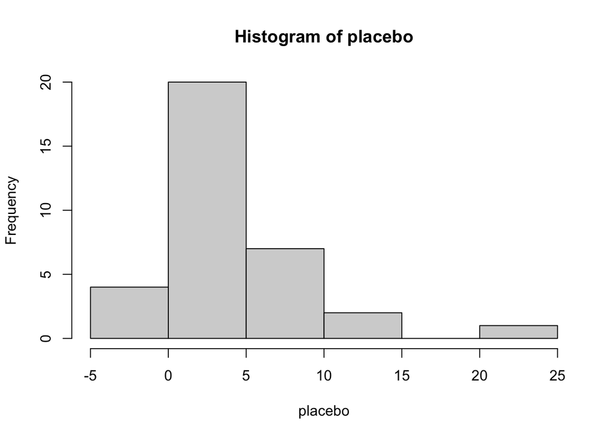

```r
hist(placebo)
```

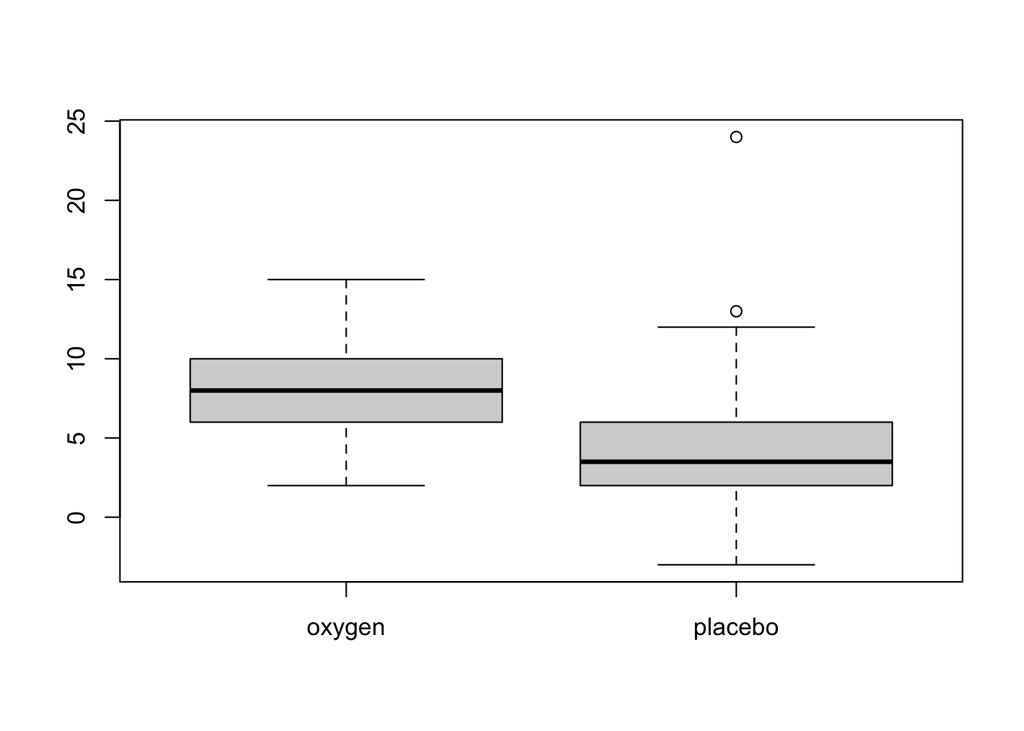

```r
# check outliers
boxplot(gel)
```

```r
## paired t-test

t.test(oxygen, placebo)
```

```
##
##  Welch Two Sample t-test
##
## data:  oxygen and placebo
## t = 3.4787, df = 61.449, p-value = 0.0009321
## alternative hypothesis: true difference in means is not equal to 0
## 95 percent confidence interval:
##  1.548450 5.733903
## sample estimates:
## mean of x mean of y
##  8.200000  4.558824
```

```r
# p-value = 0.0009321
# 95 CI = 1.548450 - 5.733903
# mu_oxygen = 8.20
# mu_placebo = 4.56


## test variance

var.test(oxygen, placebo)
```

```
##
##  F test to compare two variances
##
## data:  oxygen and placebo
## F = 0.64022, num df = 29, denom df = 33, p-value = 0.2261
## alternative hypothesis: true ratio of variances is not equal to 1
## 95 percent confidence interval:
##  0.3146534 1.3247171
## sample estimates:
## ratio of variances
##          0.6402219
```

```r
# p-value = 0.2261
# 95 CI =  0.3146534 - 1.3247171
# variances are equal

t.test(oxygen, placebo, var.eq = T)
```

```
##
##  Two Sample t-test
##
## data:  oxygen and placebo
## t = 3.4306, df = 62, p-value = 0.001077
## alternative hypothesis: true difference in means is not equal to 0
## 95 percent confidence interval:
##  1.519477 5.762876
## sample estimates:
## mean of x mean of y
##  8.200000  4.558824
```

```r
# p-value = 0.001077
# 95 CI = 1.519477 - 5.762876
```

5. ANSWER: I would run a *Wilcoxon rank sum test* because we are comparing the mean between two groups (potassium vs electrolytic oxygen) but their distributions are not normal with some outliers.
- H0 (null hypothesis): The true location shift is equal to 0 (median) for the potassium vs electrolytic oxygen groups. (M_d = 0)
- HA (alternative hypothesis): The true location shift is not equal to 0 (median) for the potassium vs electrolytic oxygen groups. (M_d /= 0)

In conclusion, *there is no significant difference* in the median between the potassium vs electrolytic oxygen groups. The *p value is 0.6961*, which is > 0.05 and means we fail to reject our H0.

```r
## upload data
potassium <- c(1.42920, 1.42860, 1.42906, 1.42957, 1.42910, 1.42930, 1.42945)

electrolytic <- c(1.42932, 1.42908, 1.42910, 1.42951, 1.42933, 1.42905, 1.42914, 1.42849, 1.4294, 1.42886)

group <- cbind(potassium, electrolytic)
## visualize data

# check distribution
library(car)
```

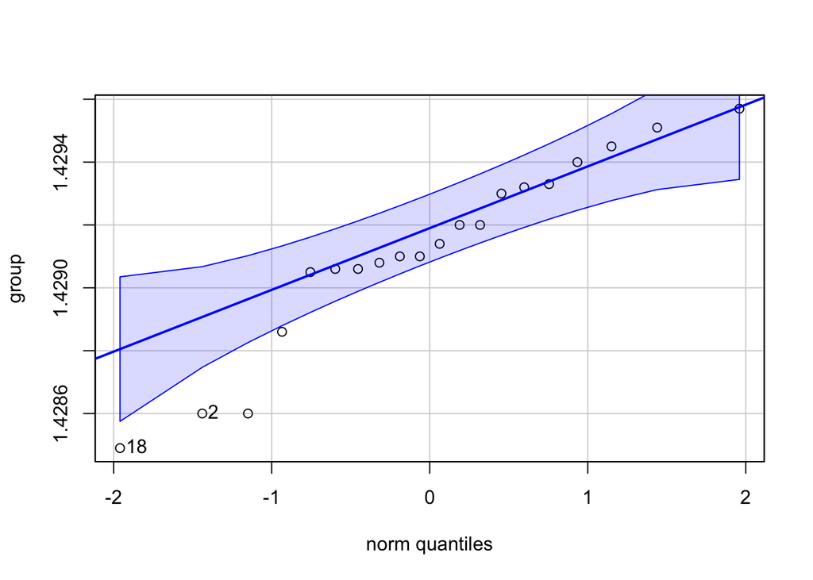

```
## [1] 18  2
```

```r
qqPlot(group)
```

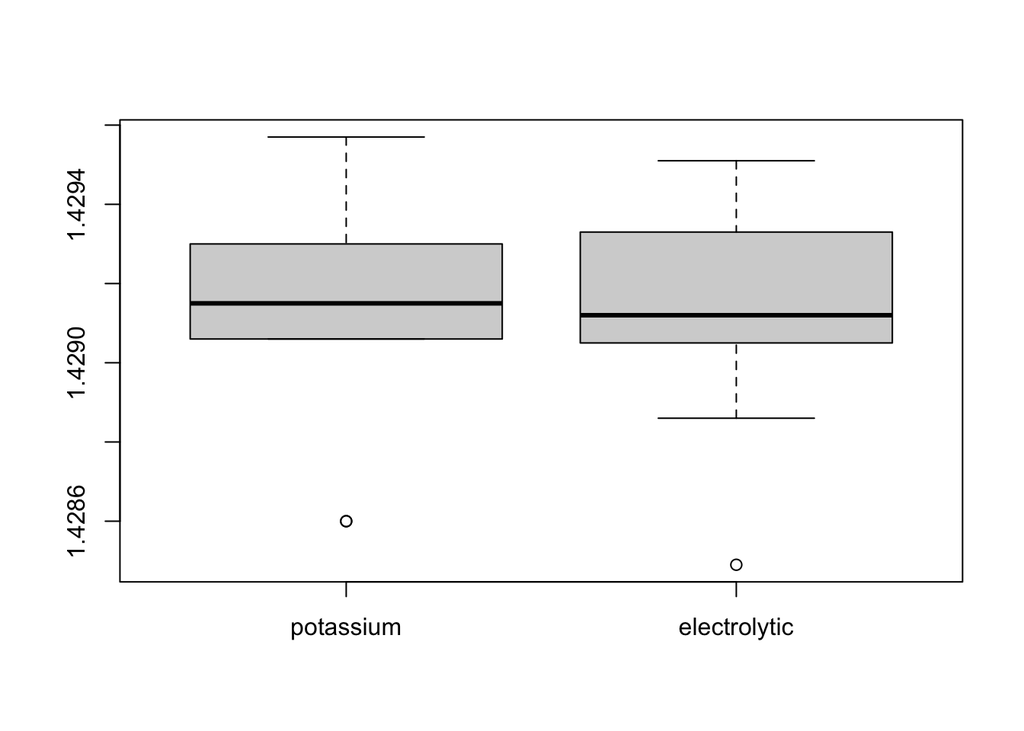

```r
# check outliers
boxplot(group)
```

```r
# compute wilcoxon signed rank test
wilcox.test(potassium, electrolytic)
```

```
##
##  Wilcoxon rank sum test with continuity correction
##
## data:  potassium and electrolytic
## W = 39.5, p-value = 0.6961
## alternative hypothesis: true location shift is not equal to 0
```

```r
# W = 39.5
# p-value = 0.6961
```

6. ANSWER: I would run a *two Sample t-test (unequal variance)* because we are comparing the mean between two groups (chemical vs air). The distribution of both groups are trending normal, although there are two slight outliers. And the variances are un-equal (p = 4.234e-06).
- H0 (null hypothesis): There is no difference in the mean density of nitrogen between the chemical compounds and air groups. (mu_chemical = mu_air)
- HA (alternative hypothesis): There is a difference in the mean density of nitrogen between the chemical compounds and air groups.

In conclusion, *there is a significant difference* in the mean density of nitrogen between the chemical compounds and air groups. The *p value is 8.594e-08*, which is < 0.05 and means we can reject our H0. Also, because our 95% CI (-0.01180801 - -0.00949949) does not include 0, then we know the mean of both groups are not equal to 0. The mean oral index for chemical compounds and air, are 2.29 and 2.31, respectively.

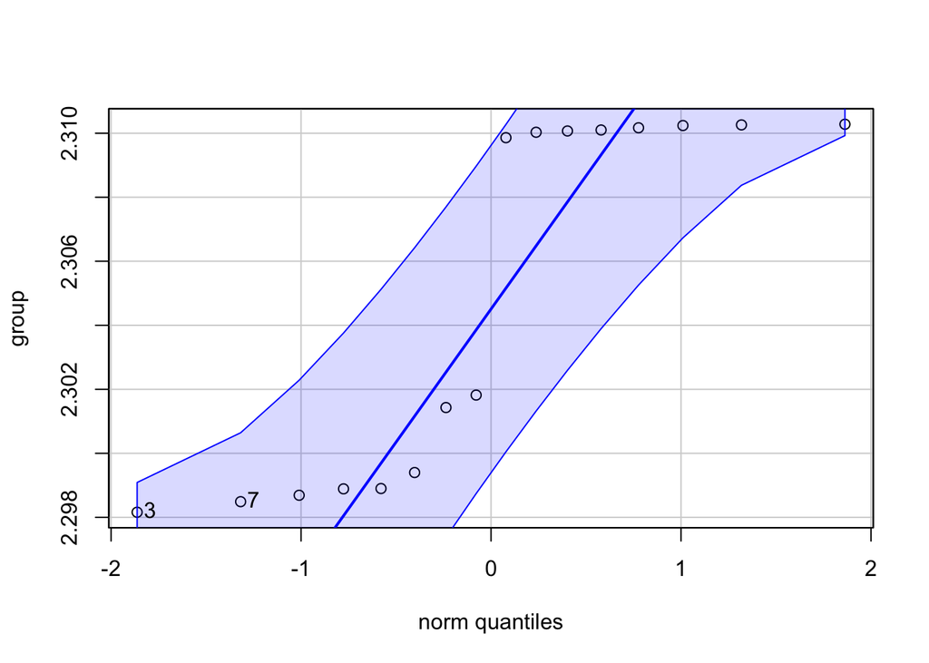

```
## [1] 3 7
```

```r
## upload data
chemical <- c(2.30143, 2.29890, 2.29816, 2.30182, 2.29869, 2.29940, 2.29849, 2.29889)

air <- c(2.31026, 2.31017, 2.30986, 2.31003, 2.31007, 2.31024, 2.31010, 2.31028)

group <- cbind(chemical, air)

## visualize data

# check distribution
library(car)
qqPlot(group)
```

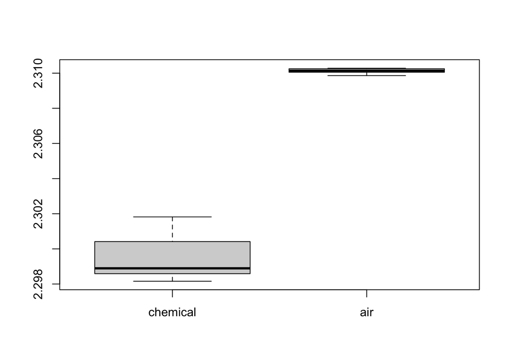

```r
# check outliers
boxplot(group)
```

```r
## test variance

var.test(chemical, air)
```

```
##
##  F test to compare two variances
##
## data:  chemical and air
## F = 94.846, num df = 7, denom df = 7, p-value = 4.234e-06
## alternative hypothesis: true ratio of variances is not equal to 1
## 95 percent confidence interval:
##   18.98847 473.74564
## sample estimates:
## ratio of variances
##           94.84569
```

```r
# p-value = 4.234e-06
# 95 CI =  18.98847 473.74564
# variances are NOT equal

t.test(chemical, air, var.eq = F)
```

```
##
##  Welch Two Sample t-test
##
## data:  chemical and air
## t = -21.734, df = 7.1476, p-value = 8.594e-08
## alternative hypothesis: true difference in means is not equal to 0
## 95 percent confidence interval:
##  -0.01180801 -0.00949949
## sample estimates:
## mean of x mean of y
##  2.299473  2.310126
```

```r
# p-value = 8.594e-08
# 95 CI = -0.01180801 -0.00949949
# mu_chemical = 2.29
# mu_air = 2.31
```

7. ANSWER: I would run a *two Sample t-test (equal variance)* because we are comparing the mean between two groups (music vs no music). The distribution of both groups is trending normal. And the variances are equal (p = 0.3048).
- H0 (null hypothesis): There is no difference in the mean productivity between the music and non music groups. (mu_music = mu_nomusic)
- HA (alternative hypothesis): There is a difference in the mean productivity between the music and non music groups.

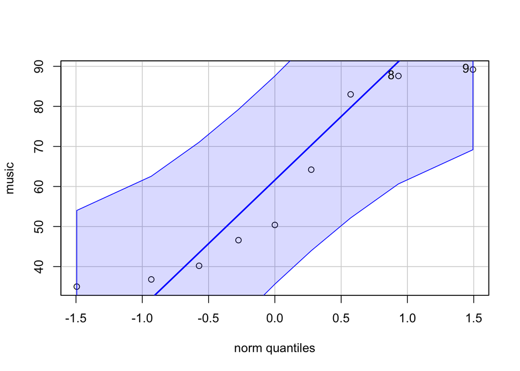

```
## [1] 9 8
```

```r
## upload data
music <- c(35, 36.8, 40.2, 46.6, 50.4, 64.2, 83, 87.6, 89.2)
no_music <- c(28.2, 28.6, 33, 34.8, 45.4, 50.8, 52.6, 66.4, 67.8)

group <- cbind(music, no_music)

## visualize data

# check distribution
library(car)
qqPlot(music)
```

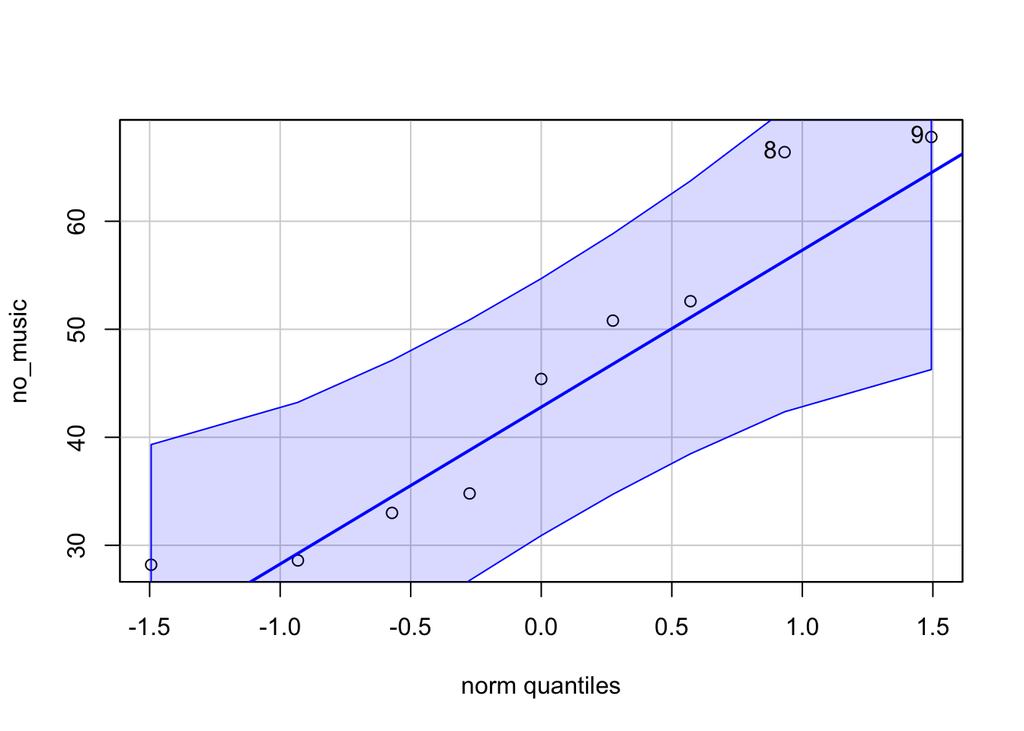

```
## [1] 9 8
```

```r
qqPlot(no_music)
```

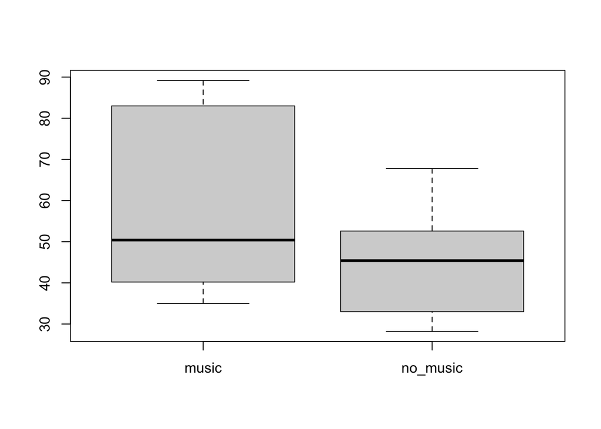

```r
# check outliers
boxplot(group)
```

```r
## test variance

var.test(music, no_music)
```

```
##
##  F test to compare two variances
##
## data:  music and no_music
## F = 2.1322, num df = 8, denom df = 8, p-value = 0.3048
## alternative hypothesis: true ratio of variances is not equal to 1
## 95 percent confidence interval:
##  0.4809515 9.4525212
## sample estimates:
## ratio of variances
##           2.132183
```

```r
# p-value = 0.3048
# 95 CI =  0.4809515 - 9.4525212
# variances are equal

t.test(music, no_music, var.eq = T)
```

```
##
##  Two Sample t-test
##
## data:  music and no_music
## t = 1.5457, df = 16, p-value = 0.1417
## alternative hypothesis: true difference in means is not equal to 0
## 95 percent confidence interval:
##  -5.175961 33.042627
## sample estimates:
## mean of x mean of y
##  59.22222  45.28889
```

```r
# p-value = 0.1417
# 95 CI = -5.175961 33.042627
# mu_music = 59.22222
# mu_nomusic = 45.28889
```

8. ANSWER: I would run a *Wilcoxon rank sum test* because we are comparing the mean between two groups (male vs female) but their distributions are not normal with some outliers.
- H0 (null hypothesis): The true location shift is equal to 0 (median) for the male vs females groups. (M_d = 0)
- HA (alternative hypothesis): The true location shift is not equal to 0 (median) for the male vs females groups. (M_d /= 0)

```r
## upload data

males <- c(40, 76, 89, 106, 120, 130, 150, 155, 382)
females <- c(66,69, 94, 103, 117, 391)

group <- cbind(males, females)
```

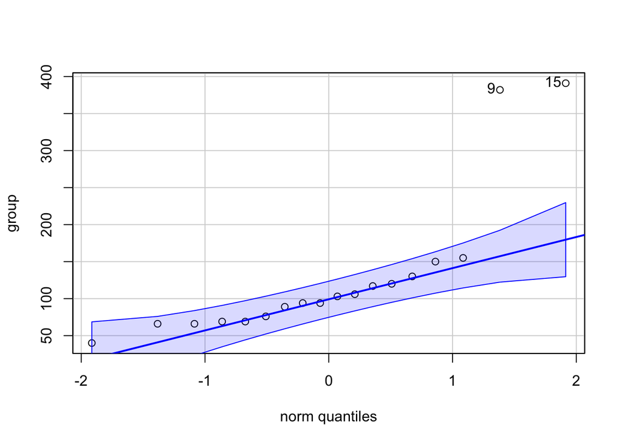

```
## [1] 15  9
```

```r
## visualize data

# check distribution
library(car)
qqPlot(group)
```

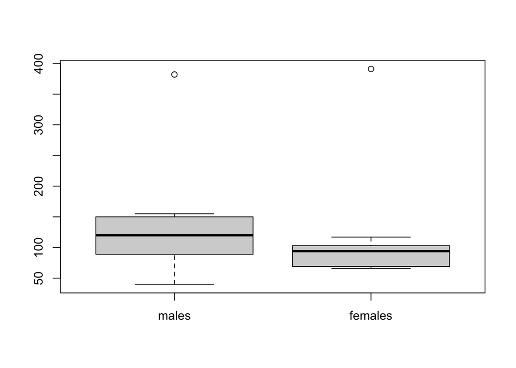

```r
# check outliers
boxplot(group)
```

```r
wilcox.test(males, females)
```

```
##
##  Wilcoxon rank sum exact test
##
## data:  males and females
## W = 33, p-value = 0.5287
## alternative hypothesis: true location shift is not equal to 0
```

```r
# p-value = 0.5287
# W = 33
```

1. ANSWER: I will use a two-sample t-test since I generated/simulated two populations (high and low) with a normal distribution.
- H0 (null hypothesis): The mean lifetime of the population of high activity flies is equal to the mean lifetime of the population of low flies. (mu_high = mu_low)
- HA (alternative hypothesis): The mean lifetime of the population of high activity flies is not equal to the mean lifetime of the population of low flies